# Bio4158/Bio5158 - Report 2

- Show All Code
- Hide All Code
- View Source

Exercise

Author

Group 22 - Nalan Kurnaz

Published

October 1, 2025

## 1 The problem

Black fly larvae (Diptera: Simuliidae) were sampled in February at the outlet of two lakes of the Eastern Townships (Lakes Orford and Lovering). The body length of each larva was measured. The data are in the file `simulies.csv` The relationship between body length (L, in mm) and dry mass (M, in $\mu$g) for the dominant species (*P. mixtum/fuscum*) is:

$$M = 1.36 L^{3.05}$$

Analyze the data and answer the questions. *Total = 20 points*

The effect size `d` is estimate as:

$$d = \frac{\left|\mu_2 - \mu_1\right|}{\sqrt{\frac{sd_1^2 + sd_2^2}{2}}}$$

## 2 The task

### 2.1 Site specific summary statistics

#### 2.1.1 Data Preprocessing

```r
#importing libraries, reading the data
#install.packages("pwr")
library(dplyr)
library(pwr)
library(ggplot2)

simulies_data <- read.csv("https://raw.githubusercontent.com/nalank1/r-files/refs/heads/main/data-bioxx58/simulies.csv", header=TRUE, sep=",", stringsAsFactors=TRUE)
str(simulies_data)
```

```
'data.frame':   615 obs. of  2 variables:
 $ Site  : Factor w/ 2 levels "Lovering","Orford": 2 2 2 2 2 2 2 2 2 2 ...
 $ Length: num  4.1 2.8 2.2 3.2 3.2 3.1 3.1 4.1 4.1 3.2 ...
```

```r
sum(is.na(simulies_data))
```

```
[1] 0
```

**To do**

Calculate the mean mass and its standard deviation at each site. *(4 points)*

```r
for (i in 1:length(simulies_data$Length)){
  simulies_data$Mass[i] <- 1.36* (simulies_data$Length[i]**(3.05))

}
summary <- simulies_data %>%
group_by(Site) %>%
summarize(mean_mass = mean(Mass), standard_deviation = sd(Mass))

summary
```

```
# A tibble: 2 × 3
  Site     mean_mass standard_deviation
  <fct>        <dbl>              <dbl>
1 Lovering      13.1               23.8
2 Orford        43.0               48.0
```

The mean mass of Lovering and Orford is 13.1 and 43.0, respectively. Their standard deviation is 23.8 and 48.0 for Lovering and Orford, respectively.

### 2.2 Power

**To do**

Using the standard deviations observed at each site, calculate the power of a two-tailed t test for independent means *(4 points)*

#### 2.2.1

**To do**

if the mass difference was 5 $\mu$g, $\alpha$=0.05, and that 100 larvae were sampled at each site

```r
## calculating the power of a two-tailed t test

orford_mean <- summary %>%
filter(Site == "Orford") %>% pull(mean_mass)
orford_sd <- summary %>%
filter(Site == "Orford") %>% pull(standard_deviation)

lovering_mean <- summary %>%
filter(Site == "Lovering") %>% pull(mean_mass)
lovering_sd <- summary %>%
filter(Site == "Lovering") %>% pull(standard_deviation)

# d <- abs(orford_mean - lovering_mean) / sqrt(((orford_sd**2) + (lovering_sd**2))/2)

d1 <- 5 / sqrt(((orford_sd**2) + (lovering_sd**2))/2)

pwr <- pwr.t.test(n = 100, d1, sig.level = 0.05, type = "two.sample", alternative = "two.sided")
print(pwr)
```

```
     Two-sample t test power calculation

              n = 100
              d = 0.1319744
      sig.level = 0.05
          power = 0.1531382
    alternative = two.sided

NOTE: n is number in *each* group
```

Based on the sample size = 100, effect size = 0.1319744 and alpha = 0.05, the power of the two-tailed t-test is 0.1531382.

#### 2.2.2

**To do**

if the mass difference was 20 $\mu$g, $\alpha$=0.05, and that 100 larvae were sampled at each site

```r
d2 <- 20 / sqrt(((orford_sd**2) + (lovering_sd**2))/2)
pwr2 <- pwr.t.test(n = 100, d2, sig.level = 0.05, type = "two.sample", alternative = "two.sided")
pwr2
```

```
     Two-sample t test power calculation

              n = 100
              d = 0.5278978
      sig.level = 0.05
          power = 0.9603422
    alternative = two.sided

NOTE: n is number in *each* group
```

Based on the sample size = 100, effect size = 0.5278978 and the significance level = 0.05, the power of the two-tailed t-test is 0.9603422.

#### 2.2.3

**To do**

if the mass difference was 50 $\mu$g, $\alpha$=0.05, and that 100 larvae were sampled at each site

```r
d3 <- 50 / sqrt(((orford_sd**2) + (lovering_sd**2))/2)

pwr3 <- pwr.t.test(n = 100, d3, sig.level=0.05, type = "two.sample", alternative = "two.sided")

pwr3
```

```
     Two-sample t test power calculation

              n = 100
              d = 1.319744
      sig.level = 0.05
          power = 1
    alternative = two.sided

NOTE: n is number in *each* group
```

Based on the sample size = 100, effect size = 1.319744 and the significance level = 0.05, the power of the two-tailed t-test is 1.

#### 2.2.4

**To do**

Comment on how changing the mass difference affects power.

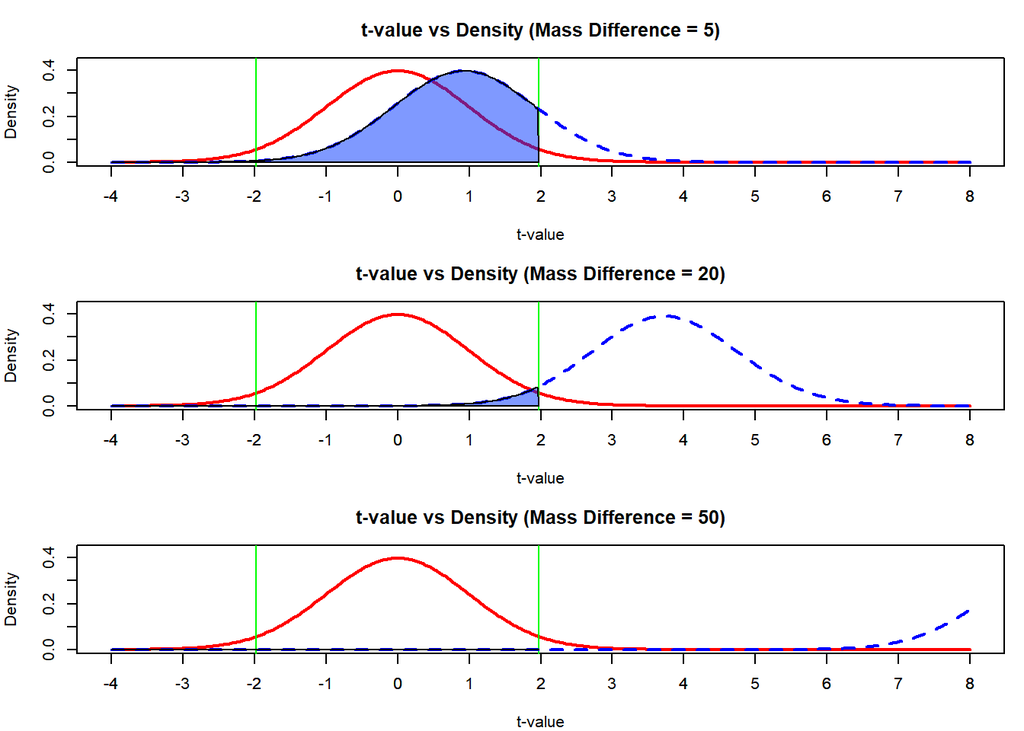

```r
plot_power <- function(d_value, title = "Power Plot"){
  df <- 198
  x <- seq(-4, 8, length = 400)
  y0 <- dt(x, df) #H0
  y1 <- suppressWarnings(dt(x, df, ncp = d_value * sqrt(200)/2)) #H1

  plot(x, y0, type = "l", col = "red", lwd = 2, ylim = c(0, max(y0, y1) * 1.1), main = title, ylab = "Density", xlab = "t-value")
  axis(1, at = seq(min(x), max(x)))

  qc <- qt(0.025, df)

  abline(v = qc, col = "green")
  abline(v = -qc, col = "green")

  lines(x, y1, type = "l", col = "blue", lwd = 2, lty = 2)

  polygon(
    c(x[x <= -qc], -qc),
    c(y1[x <= -qc], 0),
    col = rgb(0, 0.2, 1, alpha=0.5)
  )
}

par(mfrow = c(3,1), mar = c(4,4,3,1))
plot_power(d1, title = "t-value vs Density (Mass Difference = 5)")
plot_power(d2, title = "t-value vs Density (Mass Difference = 20)")
plot_power(d3, title = "t-value vs Density (Mass Difference = 50)")
```

As seen in the previous graphs, increasing the mass difference between groups leads to higher statistical power in the two-tailed t-test. In other words, as the mass difference increases, the probability of having a Type II error (failing to reject a false null hypothesis) decreases.

### 2.3 Required sample size

**To do**

Calculate the required sample size to detect, with a two-tailed t-test for independent means, a difference of 50 $\mu$g between the means *(4 points)*

#### 2.3.1

**To do**

with a power of 80% and $\alpha$=0.05

```r
d_cohen <- 50 / sqrt(((orford_sd**2) + (lovering_sd**2))/2)

n1 <- pwr.t.test(d = d_cohen, sig.level = 0.05, power = 0.8, type = "two.sample", alternative = "two.sided")

n1
```

```
     Two-sample t test power calculation

              n = 10.06992
              d = 1.319744
      sig.level = 0.05
          power = 0.8
    alternative = two.sided

NOTE: n is number in *each* group
```

The required sample size is 11 for each group.

#### 2.3.2

**To do**

with a power of 80% and $\alpha$=0.001

```r
n2 <- pwr.t.test(d = d_cohen, sig.level = 0.001, power = 0.8, type = "two.sample", alternative = "two.sided")

n2
```

```
     Two-sample t test power calculation

              n = 22.36307
              d = 1.319744
      sig.level = 0.001
          power = 0.8
    alternative = two.sided

NOTE: n is number in *each* group
```

The required sample size is 23 for each group.

#### 2.3.3

**To do**

with a power of 95% and $\alpha$=0.05.

```r
n3 <- pwr.t.test(d = d_cohen, sig.level = 0.05, power = 0.95, type = "two.sample", alternative = "two.sided")

n3
```

```
     Two-sample t test power calculation

              n = 15.95018
              d = 1.319744
      sig.level = 0.05
          power = 0.95
    alternative = two.sided

NOTE: n is number in *each* group
```

The required sample size for two-tailed t-test with 2 independent means, given the power of 95% and alpha = 0.05, is 16 for each group.

#### 2.3.4

**To do**

Comment on how changing power and $\alpha$ affects the required sample size.

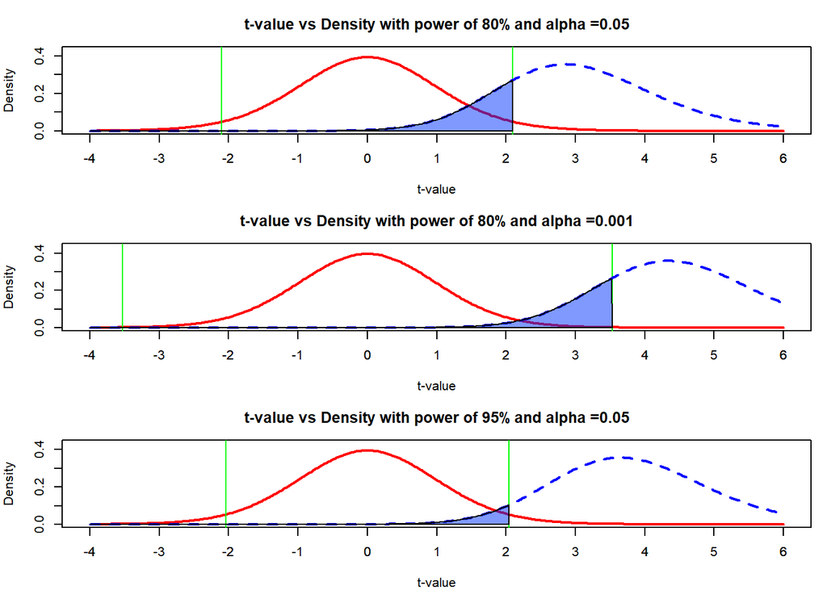

```r
plot_power <- function(n_value, alpha = alpha, power = power, title = "Sample Size Plot"){
  df <- (2*(n_value) - 2)
  x <- seq(-4, 6, length = 400)
  y0 <- dt(x, df) #H0
  y1 <- suppressWarnings(dt(x, df, ncp = d_cohen * sqrt((2*n_value))/2)) #H1

  plot(x, y0, type = "l", col = "red", lwd = 2, ylim = c(0, max(y0, y1) * 1.1), main = title, ylab = "Density", xlab = "t-value")
  axis(1, at = seq(min(x), max(x)))

  qc_1 <- qt(alpha/2, df)
  abline(v = qc_1, col = "green")
  abline(v = -qc_1, col = "green")

  lines(x, y1, type = "l", col = "blue", lwd = 2, lty = 2)

  polygon(
    c(x[x <= -qc_1], -qc_1),
    c(y1[x <= -qc_1], 0),
    col = rgb(0, 0.2, 1, alpha=0.5)
  )
}


par(mfrow = c(3,1), mar = c(4,4,3,1))
plot_power(n1$n, alpha = 0.05, power = 0.8, title = "t-value vs Density with power of 80% and alpha =0.05")
plot_power(n2$n, alpha = 0.001, power = 0.8, title = "t-value vs Density with power of 80% and alpha =0.001")
plot_power(n3$n, alpha = 0.05, power = 0.95, title = "t-value vs Density with power of 95% and alpha =0.05")
```

Increasing the power (1-$\beta$) or decreasing the significance level ($\alpha$) both increase the required sample size. This is because higher power or lower significance level require more data to reliably detect an effect.

### 2.4 Detectable effect size

**To do**

Calculate the detectable effect size (`d`) with a two-tailed t-test on independent means, given the observed standard deviations *(4 points)*

#### 2.4.1

**To do**

With a power of 80%, $\alpha$=0.05, and measurements on 10 larvae at each site

```r
d1_find <- pwr.t.test(n = 10, sig.level = 0.05, power = 0.8, type = "two.sample", alternative = "two.sided")

d1_find
```

```
     Two-sample t test power calculation

              n = 10
              d = 1.324947
      sig.level = 0.05
          power = 0.8
    alternative = two.sided

NOTE: n is number in *each* group
```

The detectable effect size with a two-tailed t-test on independent means, given the power of 80%, alpha = 0.05 and sample size = 10, is 1.324947.

#### 2.4.2

**To do**

With a power of 80%, $\alpha$=0.05, and measurements on 200 larvae at each site

```r
d2_find <- pwr.t.test(n = 200, sig.level = 0.05, power = 0.8, type = "two.sample", alternative = "two.sided")

d2_find
```

```
     Two-sample t test power calculation

              n = 200
              d = 0.2808267
      sig.level = 0.05
          power = 0.8
    alternative = two.sided

NOTE: n is number in *each* group
```

The detectable effect size for two-tailed t-test for independent means, given the power is 80%, alpha = 0.05 and sample size = 200, is 0.2808267.

#### 2.4.3

**To do**

With a power of 80%, $\alpha$=0.05, and measurements on 20 larvae at one site and 380 larvae at the second site

```r
d3_find <- pwr.t2n.test(n1 = 20, n2 = 380, sig.level = 0.05, power = 0.8, alternative = "two.sided")

d3_find
```

```
     t test power calculation

             n1 = 20
             n2 = 380
              d = 0.6442829
      sig.level = 0.05
          power = 0.8
    alternative = two.sided
```

The detectable effect size for two-tailed t-test for independent means, given the power is 80%, alpha = 0.05, n1 = 20 and n2 = 380, is 0.6442829.

#### 2.4.4

**To do**

Comment on how changing sample sizes affect `d`.

[figure not shown]

```r
plot_power <- function(n_value, d, alpha = alpha, power = power, title = "Sample Size Plot"){
  if(d == d3_find$d){
    df <- d3_find$n1 + d3_find$n2 - 2
    x <- seq(-4, 6, length = 400)
    y0 <- dt(x, df) #H0
    y1 <- suppressWarnings(dt(x, df, ncp = d * sqrt((d3_find$n1 * d3_find$n2) / (d3_find$n1 + d3_find$n2))))
  }
  else{
    df <- (2*(n_value) - 2)
    x <- seq(-4, 6, length = 400)
    y0 <- dt(x, df) #H0
    y1 <- suppressWarnings(dt(x, df, ncp = d * sqrt((2*n_value))/2)) #H1
  }


  plot(x, y0, type = "l", col = "red", lwd = 2, ylim = c(0, max(y0, y1) * 1.1), main = title, ylab = "Density", xlab = "t-value")

  axis(1, at = seq(min(x), max(x)))

  qc_1 <- qt(alpha/2, df)
  abline(v = qc_1, col = "green")
  abline(v = -qc_1, col = "green")

  lines(x, y1, type = "l", col = "blue", lwd = 2, lty = 2)

  polygon(
    c(x[x <= -qc_1], -qc_1),
    c(y1[x <= -qc_1], 0),
    col = rgb(0, 0.2, 1, alpha=0.5)
  )

}

par(mfrow = c(3,1), mar = c(4,4,3,1))
plot_power(d1_find$n, d1_find$d, alpha = 0.05, power = 0.8, title = "t-value vs Density with power of 80%, alpha=0.05 and n = 10")

plot_power(d2_find$n, d2_find$d, alpha = 0.05, power = 0.8, title = "t-value vs Density with power of 80%, alpha = 0.001 and n = 200")

plot_power((d3_find$n1+d3_find$n2), d3_find$d, alpha = 0.05, power = 0.8, title = "t-value vs Density with power of 95%, alpha=0.05 and n1,n2 = 20, 380")
```

Increasing sample size decreases the minimum detectable effect size (`d`), allowing detection of smaller differences. When sample sizes are unequal, a large imbalance increases the minimum detectable effect size.

### 2.5 Differences in average mass

**To do**

Calculate the difference in average mass, in $\mu$g, that can be detected given your estimate of the minimum detectable effect size (`d`) at 2.4.1-2.4.3 *(4 points)*

```r
sp <- sqrt((orford_sd**2 + lovering_sd**2) / 2)

d_findings <- c(d1_find$d, d2_find$d, d3_find$d)

for (i in 1:length(d_findings)){
  calc <- d_findings[i] * sp
  print(sprintf("The difference in average mass for the Experiment %d is %.2f", i, calc))
}
```

```
[1] "The difference in average mass for the Experiment 1 is 50.20"
[1] "The difference in average mass for the Experiment 2 is 10.64"
[1] "The difference in average mass for the Experiment 3 is 24.41"
```

The minimum detectable difference in average mass is approximately 50.20 μg for Experiment 1 ( n = 10), 10.64 μg for Experiment 2 (n = 200), and 24.41 μg for Experiment 3 (n1 = 20, n2 = 380).